# Cluster Analysis Research Report

An Investigation into the StarWars Data

Paul Kieffaber

2025-11-17

**Goal.** Pick a publicly available dataset, ask a concrete question about how observations might group together, then (1) determine a sensible number of clusters using the elbow and silhouette methods, (2) compare K‑means, Hierarchical (Ward.D2), and DBSCAN, (3) select and justify a final solution, and (4) compare clusters on at least one validation variable not used to form clusters.

# The Star Wars Dataset

The starwars dataset (included in the dplyr package) contains information on 87 characters from the Star Wars universe.

- Some Key variables:

```
## Rows: 87
## Columns: 14
## $ name       <chr> "Luke Skywalker", "C-3PO", "R2-D2", "Darth Vader", "Leia Or…
## $ height     <int> 172, 167, 96, 202, 150, 178, 165, 97, 183, 182, 188, 180, 2…
## $ mass       <dbl> 77.0, 75.0, 32.0, 136.0, 49.0, 120.0, 75.0, 32.0, 84.0, 77.…
## $ hair_color <chr> "blond", NA, NA, "none", "brown", "brown, grey", "brown", N…
## $ skin_color <chr> "fair", "gold", "white, blue", "white", "light", "light", "…
## $ eye_color  <chr> "blue", "yellow", "red", "yellow", "brown", "blue", "blue",…
## $ birth_year <dbl> 19.0, 112.0, 33.0, 41.9, 19.0, 52.0, 47.0, NA, 24.0, 57.0, …
## $ sex        <chr> "male", "none", "none", "male", "female", "male", "female",…
## $ gender     <chr> "masculine", "masculine", "masculine", "masculine", "femini…
## $ homeworld  <chr> "Tatooine", "Tatooine", "Naboo", "Tatooine", "Alderaan", "T…
## $ species    <chr> "Human", "Droid", "Droid", "Human", "Human", "Human", "Huma…
## $ films      <list> <"A New Hope", "The Empire Strikes Back", "Return of the J…
## $ vehicles   <list> <"Snowspeeder", "Imperial Speeder Bike">, <>, <>, <>, "Imp…
## $ starships  <list> <"X-wing", "Imperial shuttle">, <>, <>, "TIE Advanced x1",…
```

**Research Question** Are there unique groupings of Star Wars characters based on their physical characteristics?

# Pre‑process & feature selection

- There are three continuous variables that can be used for clustering:
  - Height
  - Mass
  - Birth_year

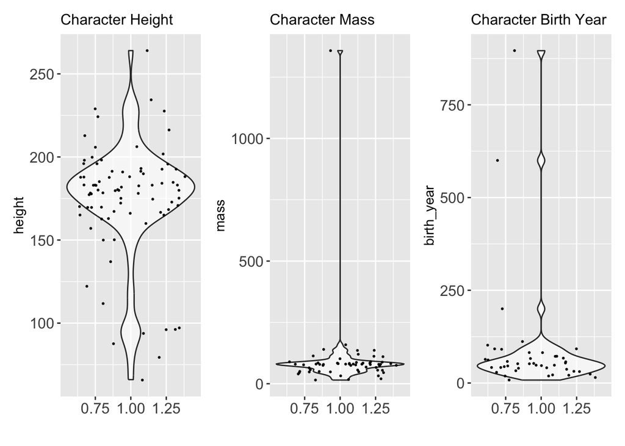

Looking at these variables, it appears that Mass>500 and Birth_year>250 will remove outliers in those variables (see filtered data below).

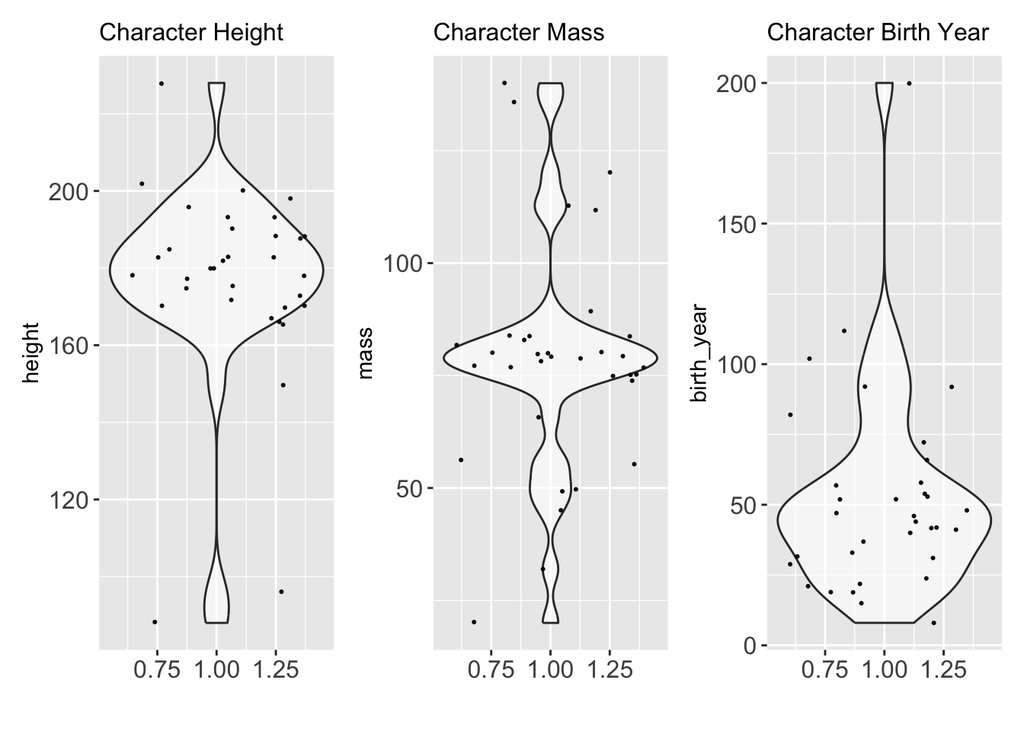

Data for clustering were then normalized (see below).

```
##           height       mass  birth_year
## [1,] -0.18628834 -0.0552317 -0.92159766
## [2,] -0.38177611 -0.1344670  1.64069180
## [3,] -3.15770240 -1.8380271 -0.53587667
## [4,]  0.98663826  2.2822111 -0.29066832
## [5,] -1.04643452 -1.1645266 -0.92159766
## [6,]  0.04829698  1.6483283 -0.01239817
```

# Decide the number of clusters with elbow & silhouette

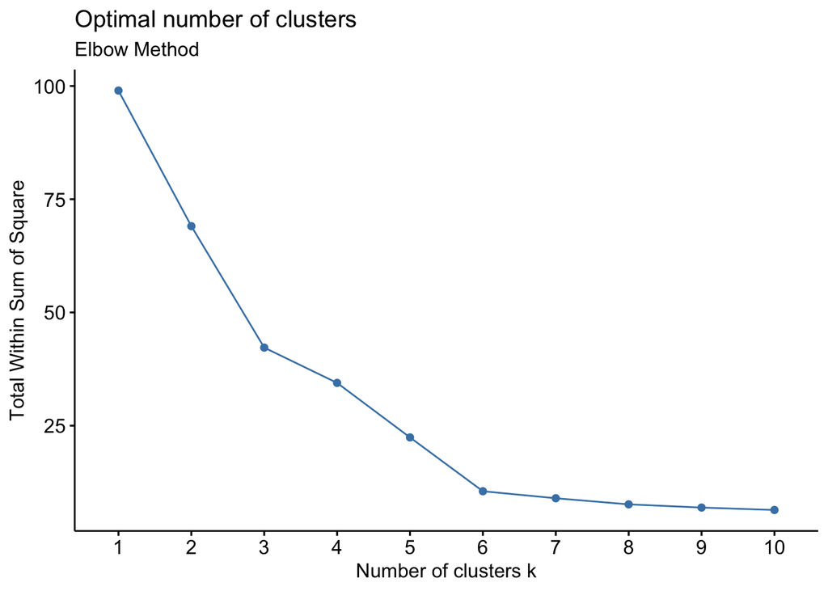

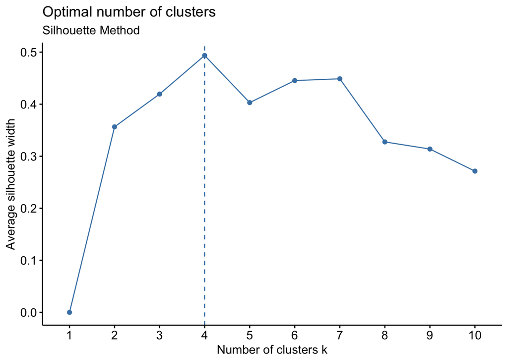

# Fit and visualize three methods

## K-means Clustering (Hartigan-Wong method)

The PCA plot shows good separation of the clusters with the two PCA dimensions accounting for more than 92% of the variabiltiy in the data.

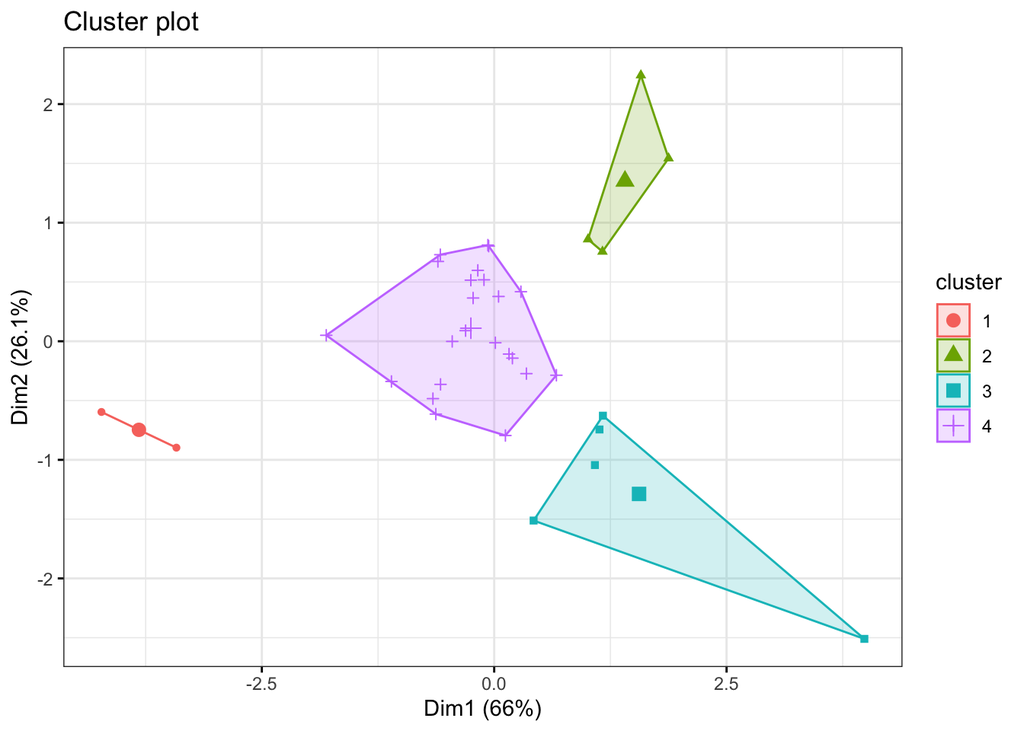

CLUSTER SUMMARY:

```
## # A tibble: 4 × 5
##   KMcluster     n Height_mean Mass_mean Age_mean
##       <int> <int>       <dbl>     <dbl>    <dbl>
## 1         1     2     -3.31      -2.08    -0.880
## 2         2     4      0.615      1.94    -0.330
## 3         3     5      0.744      0.365    1.85
## 4         4    23      0.0194    -0.235   -0.268
```

It looks like most of my clusters are pretty small. *Interpretation:*

- Cluster 1: Short, light, and young.
- Cluster 2: Tall, heavy, average age
- Cluster 3: Tall, average mass, very old
- Cluster 4: Average height, average mass, average age

## Heirarchical Clustering

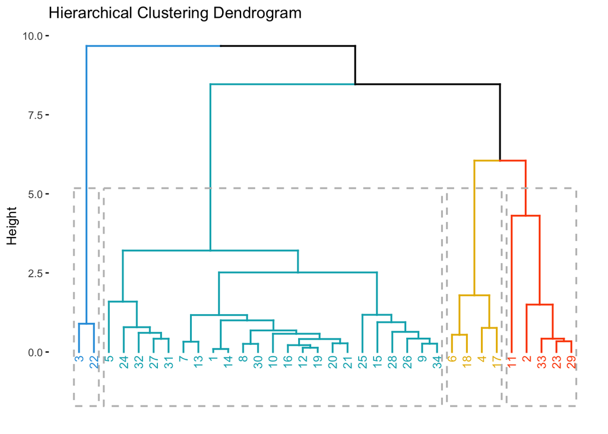

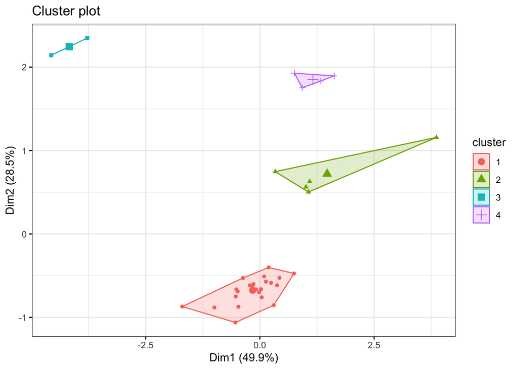

CLUSTER SUMMARY:

```
## # A tibble: 4 × 5
##   KMcluster     n Height_mean Mass_mean Age_mean
##       <int> <int>       <dbl>     <dbl>    <dbl>
## 1         1    23      0.0194    -0.235   -0.268
## 2         2     5      0.744      0.365    1.85
## 3         3     2     -3.31      -2.08    -0.880
## 4         4     4      0.615      1.94    -0.330
```

The clusters identified using hierarchical clustering are very similar to those using K-means clustering.

## Density Based Clustering (DBSCAN)

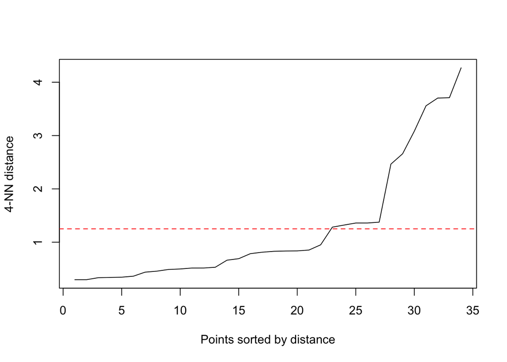

```
## DBSCAN clustering for 34 objects.
## Parameters: eps = 1.25, minPts = 5
## Using euclidean distances and borderpoints = TRUE
## The clustering contains 1 cluster(s) and 9 noise points.
##
##  0  1
##  9 25
##
## Available fields: cluster, eps, minPts, metric, borderPoints
```

Ok, so the DBSCAN method suggests there are no natural clusters, that everyone should be in the same cluster with 9 outliers.

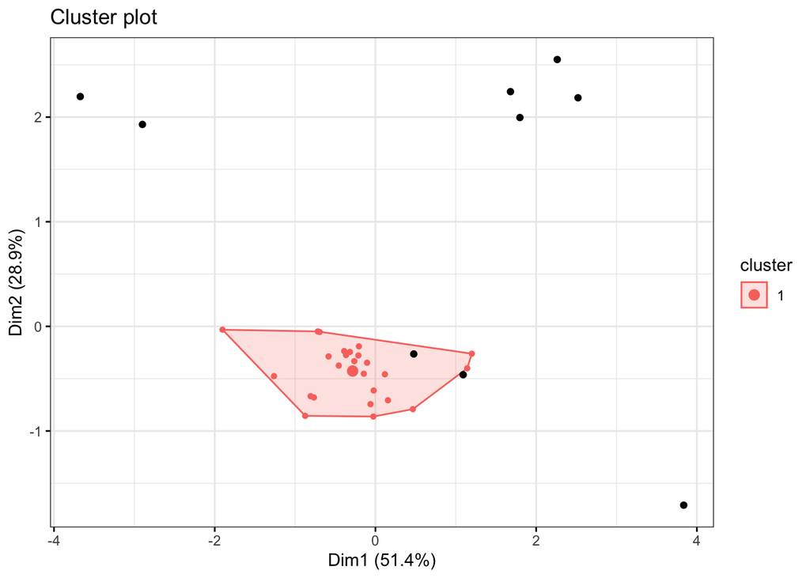

This solution seems strange. When reduced to 2 dimensions, two of the outliers fall within the cluster.

### Comparison

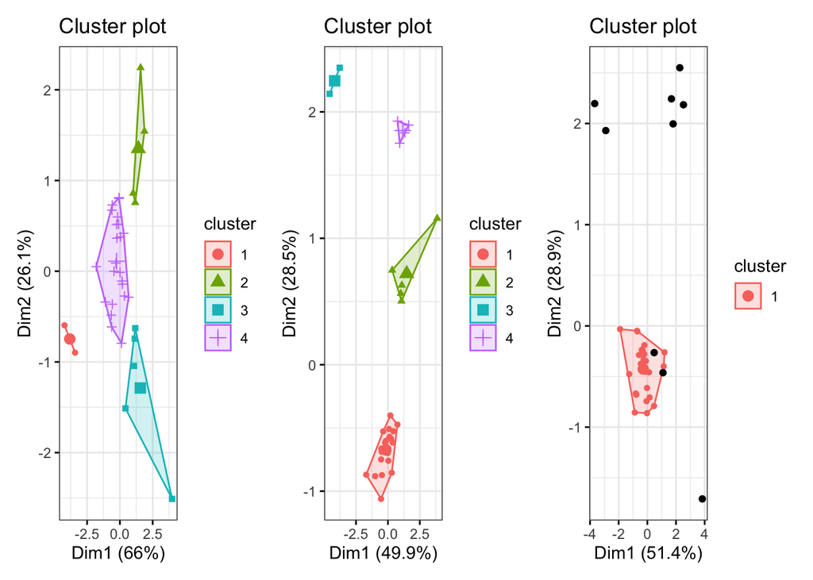

# Pick a final solution & justify Kmeans & Hierarchical were nearly identical. So I’m going to pick the k-means for validation

# Validate clusters on an external variable

[figure not shown]

In order to validate the clustering, I decided to test whether certain species were more or less likely to be in a cluster using a chi-squared test of association.

```
##
##  Pearson's Chi-squared test
##
## data:  contingency_table
## X-squared = 48.42, df = 36, p-value = 0.08085
```

The results indicate that the star wars characters are NOT clustered by physical characteristics into distinct species. The Chi-squared test did not reach statistical significance, indicating that clustering on physical attributes did not relate to species.